# Fietsendiefstallen

Willy Bakker

4 november 2017

## Fietsendiefstalgegevens

Dit document bevat voorbeeldcode voor het inlezen, verrijken, analyseren en visualiseren van fietsendiefstalgegevens van de politie Groningen.

De bronbestanden zijn gepubliceerd in de volgende GitHub repository: http://www.github.com/KennisnetwerkDataScience/fietsendiefstallen.

Het gaat om geografische gegevens. Voor meer informatie over hoe je omgaat met geografische gegevens in R kun je de volgende bronnen raadplegen:  
* [Geocomputation with R](http://robinlovelace.net/geocompr/)  
* [Spatial Data in R: New Directions](https://edzer.github.io/UseR2017/)  
* [Spatial Data in R: New Directions - video](https://channel9.msdn.com/Events/useR-international-R-User-conferences/useR-International-R-User-2017-Conference/Spatial-data-in-R-new-directions)  
* [Geospatial visualization using R](https://bhaskarvk.github.io/user2017.geodataviz/)  
* [Geospatial visualization using R - video 1](https://channel9.msdn.com/Events/useR-international-R-User-conferences/useR-International-R-User-2017-Conference/Geospatial-visualization-using-R)  
* [Geospatial visualization using R - video 2](https://channel9.msdn.com/Events/useR-international-R-User-conferences/useR-International-R-User-2017-Conference/Geospatial-visualization-using-R-II)  
* [Interactive Data Visualisation with R (and just R)](https://github.com/martinjhnhadley/2017-odsc-interactive-viz-with-R)  
* [Leaflet for R](https://rstudio.github.io/leaflet/choropleths.html)

Installeer packages en laad libraries.

```r
install.packages("devtools", repos = "http://cran.us.r-project.org",quiet = TRUE)
```

```r
devtools::install_github("tidyverse/ggplot2", repos = "http://cran.us.r-project.org", quiet = TRUE)
install.packages("tidyverse", repos = "http://cran.us.r-project.org", quiet = TRUE)
install.packages("sf", repos = "http://cran.us.r-project.org", quiet = TRUE)
install.packages("leaflet.extras", repos = "http://cran.us.r-project.org", quiet = TRUE)
library(tidyverse)
library(readxl)
library(sf)
library(leaflet.extras)
```

Lees de datasets in.

```r
download_file <- function(url, zipped = TRUE) {
  wd <- getwd()
  td <- tempdir()
  setwd(td)
  temp <- tempfile(fileext = ".zip")
  download.file(url, temp)
  unzip(temp)
  data <- read_sf(dir(tempdir(), "*.shp$"))
  unlink(dir(td))
  setwd(wd)
  return(data)
}

bushaltes <- download_file('https://github.com/KennisnetwerkDataScience/Fietsendiefstallen/raw/master/data/bushaltes.zip') %>%
             mutate(fietsenrek = ifelse(bicyclepar == 'true', TRUE, FALSE)) %>%
             select(haltenr = quaycode, haltenaam = quayname, fietsenrek) %>%
             st_transform(28992)

buurten <- download_file('https://github.com/KennisnetwerkDataScience/Fietsendiefstallen/raw/master/data/buurt2017.zip') %>%
           select(naam = BU_NAAM) %>%
           st_transform(28992)

pubs <- download_file('https://github.com/KennisnetwerkDataScience/Fietsendiefstallen/raw/master/data/horeca.zip') %>%
        filter(horecatype == 'pub') %>%
        select(naam) %>%
        st_transform(28992)

vergunningen <- download_file('https://github.com/KennisnetwerkDataScience/Fietsendiefstallen/raw/master/data/onth_verg_drank_en_horeca.zip') %>%
                filter(TYPE == 'Drank- en Horecavergunning') %>%
                select(omschrijving = OMSCHRIJVI) %>%
                st_transform(28992)

wijken <- download_file('https://github.com/KennisnetwerkDataScience/Fietsendiefstallen/raw/master/data/wijk2017.zip') %>%
          select(naam = WK_NAAM) %>%
          st_transform(28992)

diefstallen <- download_file('https://github.com/KennisnetwerkDataScience/Fietsendiefstallen/raw/master/data/diefstallen.zip') %>%
               st_transform(28992) %>%
               select(id, b_datum, e_datum, object, temp, weer) %>%
               mutate(begin = as.POSIXct(paste(b_datum, '000000'), format = "%Y%m%d%H%M%S", tz = "Europe/Amsterdam"),
                      eind  = as.POSIXct(paste(e_datum, '000000'), format = "%Y%m%d%H%M%S", tz = "Europe/Amsterdam"),
                      temp = as.numeric(ifelse(temp == "n/a", NA, temp)),
                      weer = ifelse(weer == "Geen data aanwezig", NA, weer)) %>%
               st_join(wijken, left = TRUE) %>%
               st_join(buurten, left = TRUE) %>%
               rename(wijk = naam.x, buurt = naam.y)
```

Maak een eenvoudig kaartje van het aantal diefstalen. Voeg ook de wijkgrenzen toe.

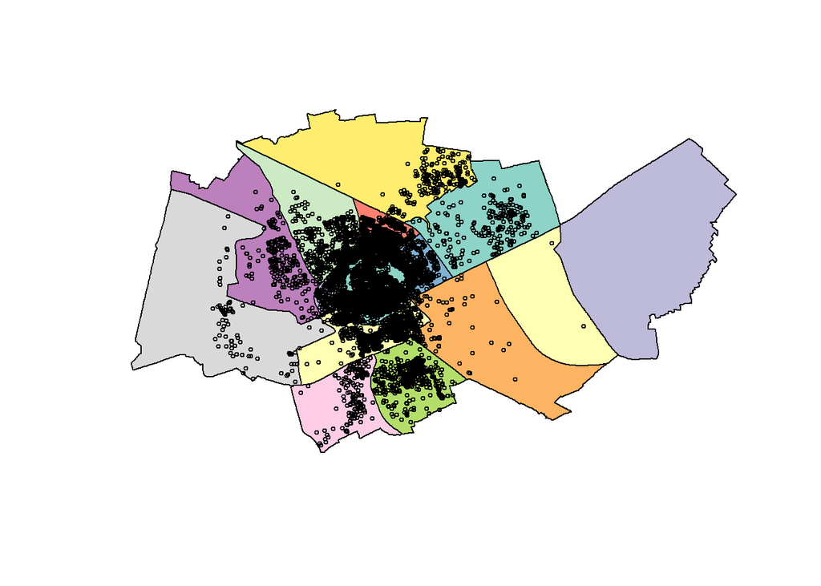

```r
plot(wijken$geometry,  col = sf.colors(nrow(wijken), categorical = TRUE))
plot(diefstallen$geometry, pch = 1, cex = 0.5, col = 1, add = TRUE)
```

Maak een kaartje van alle diefstallen in de Bloemenbuurt.

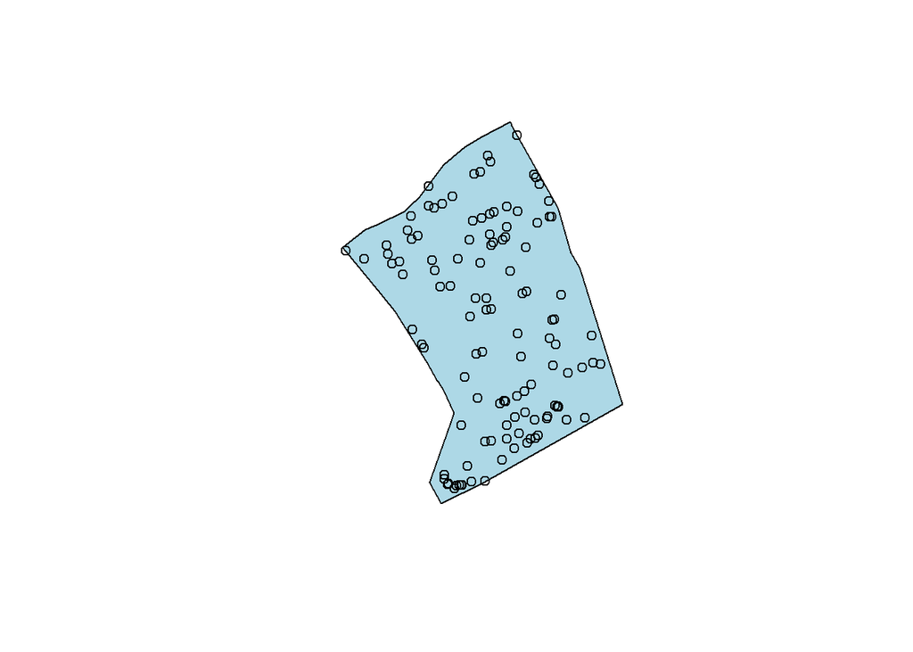

```r
wijkgrens_bloemenbuurt <- buurten %>% filter(naam == "Bloemenbuurt")
diefstallen_bloemenbuurt <- diefstallen[wijkgrens_bloemenbuurt, ]
plot(wijkgrens_bloemenbuurt$geometry, col = 'lightblue')
plot(diefstallen_bloemenbuurt$geometry, add = TRUE)
```

Maak een kaartje van alle diefstallen die NIET in een wijk van Groningen gepleegd zijn.

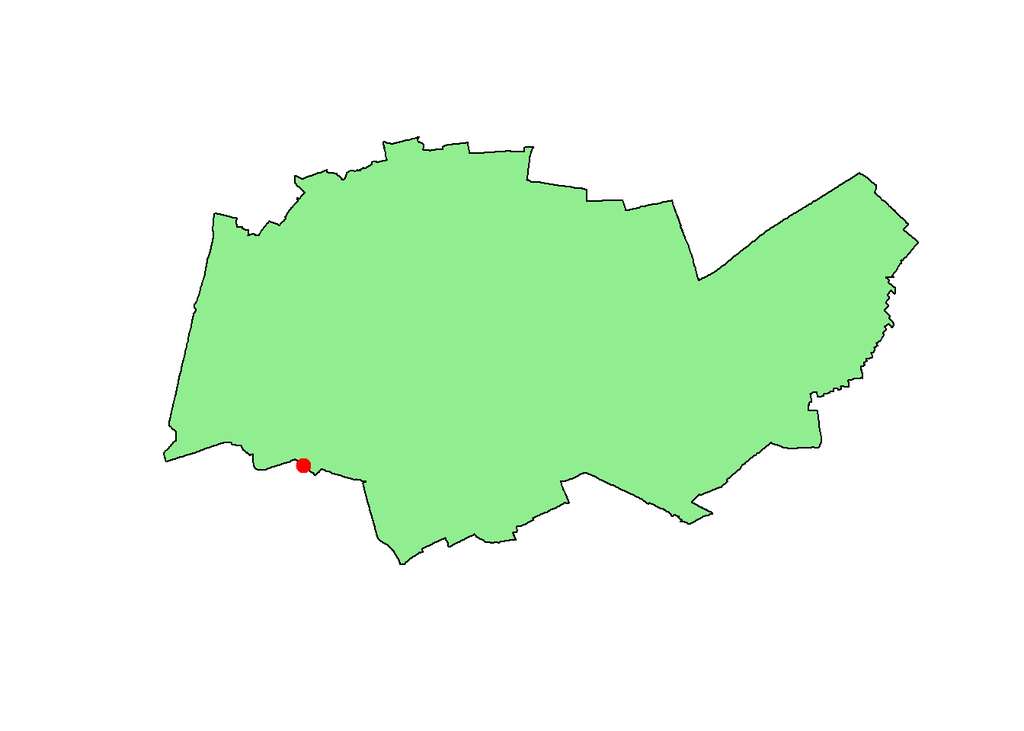

```r
stadsgrens <- st_union(wijken)
diefstallen_buiten_stadsgrens <- diefstallen[stadsgrens, op = st_disjoint]
plot(stadsgrens, col = 'lightgreen')
plot(diefstallen_buiten_stadsgrens$geometry, pch = 20, cex = 2, col = 'red', add = TRUE)
```

Er zijn 16 diefstallen gepleegd vlakbij Transferium Hoogkerk, net buiten de stad.

Vind voor iedere pub in OpenStreetMap een match in het bestand met drank- en horecavergunningen van de gemeente binnen een straal van 25 meter.

```r
selectie <- st_is_within_distance(pubs, vergunningen, dist = 25)
```

Er zijn slechts 10 pubs met een match…

Geef een overzicht van de pubs met een match.

```r
print(st_join(pubs, vergunningen, st_is_within_distance, dist = 25) %>%
      as.data.frame() %>%
      filter(!is.na(omschrijving)) %>%
      select(openstreetmap = naam, vergunning = omschrijving))
```

```
##           openstreetmap
## 1                Mulder
## 2                Mulder
## 3             de Keyzer
## 4          de Wolthoorn
## 5      Cafe Tante Truus
## 6        Cafe de Koffer
## 7            Gorechtbar
## 8       Klein Amsterdam
## 9  't Gat van Groningen
## 10          Bar Players
## 11             Buckshot
##                                                        vergunning
## 1    Mandaat D&H vergunning Grote Kromme Elleboog 13/13b 'Muller'
## 2            Turftorenstraat 6, Wolthoorn en Zn., i.v.m. overname
## 3            Turftorenstraat 6, Wolthoorn en Zn., i.v.m. overname
## 4            Turftorenstraat 6, Wolthoorn en Zn., i.v.m. overname
## 5                         Mandaat D&H vergunning, Blekerstraat 19
## 6                         Mandaat D&H vergunning, Blekerstraat 19
## 7                      Gorechtkade 3, Gorechtbar, i.v.m. overname
## 8  Poelestraat 22, Bar Players, i.v.m. toevoeging leidinggevenden
## 9                        Poelestraat 49, Cappadocie, ivm overname
## 10 Poelestraat 22, Bar Players, i.v.m. toevoeging leidinggevenden
## 11             Mandaat D&H Gedempte Zuiderdiep 56, 'Kings Garden'
```

In de uitvoer verwacht je misschien 10 regels, maar het zijn er 11. Pub ‘Mulder’ komt twee keer voor, omdat er twee matches zijn in het vergunningenbestand binnen een straal van 25 meter.

Bereken voor iedere pub de dichtsbijzijnde match in het vergunningenbestand en print ter illustratie de eerste zes rijen uit de resultaatset.

```r
pubs$vergunning <- sapply(1:nrow(pubs), function(x) vergunningen$omschrijving[which.min(st_distance(pubs[x,], vergunningen))])
pubs %>% as.data.frame() %>% select(naam, vergunning) %>% head() %>% print()
```

```
##                        naam
## 1           De drie uiltjes
## 2              Harry's cafe
## 3                      24/7
## 4         De Drie Gezusters
## 5                Streetlife
## 6 The Dogs Bollocks
##                                                                 vergunning
## 1                                      Nieuwe Ebbingestraat  7, Rode Loper
## 2 Mandaat D&H vergunning Olgerweg 6a, 'Aktiviteitencentrum Engelbert e.o.'
## 3                                   Mandaat D&H-vergunning, Akerkstraat 24
## 4           Poelestraat 22, Bar Players, i.v.m. toevoeging leidinggevenden
## 5                                 Poelestraat 49, Cappadocie, ivm overname
## 6             Mandaat D&H vergunning Grote Kromme Elleboog 13/13b 'Muller'
```

Geef voor iedere diefstal de afstand van de locatie tot de dichtstbijzijnde bushalte.  
LET OP: HET UITVOEREN VAN ONDERSTAANDE REGEL CODE KAN VEEL TIJD KOSTEN!

```r
diefstallen$afstand_tot_bushalte <- sapply(1:nrow(diefstallen), function(x) min(st_distance(diefstallen[x,], bushaltes)))
```

De kleinste afstand is 1 en de grootste 1004 meter.

Maak choropleet met het aantal diefstallen per buurt.

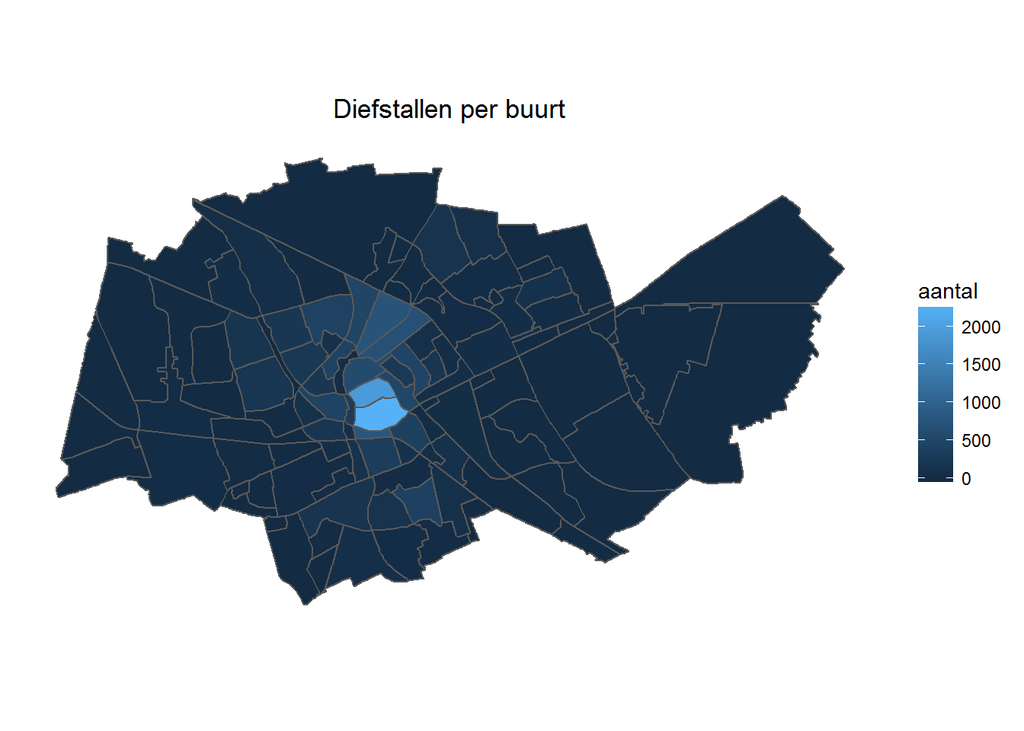

```r
buurten$aantal <- lengths(st_covers(buurten, diefstallen))

ggplot(buurten) +
  geom_sf(aes(fill = aantal)) +
  ggtitle("Diefstallen per buurt") +
  theme(axis.text.x = element_blank(),
        axis.text.y = element_blank(),
        axis.ticks = element_blank(),
        rect = element_blank(),
        plot.title = element_text(hjust = 0.5))
```

Bepaal de kwartielen van de diefstallen per buurt.

```r
quantile(buurten$aantal)
```

```
##      0%     25%     50%     75%    100%
##    0.00    2.00   34.00  133.75 2273.00
```

Maak een interactieve kaart met het aantal diefstallen per buurt.

```r
pal <- colorBin("Reds", domain = buurten$aantal, bins = c(0, 5, 50, 500, 1000, 2500))

buurten %>%
  st_transform(4326) %>%
  leaflet() %>%
  addPolygons(fillColor = ~pal(aantal),
              weight = 1,
              color = "#000000",
              fillOpacity = 0.7,
              label = ~(paste0(naam, ': ', aantal)),
              highlight = highlightOptions(weight = 5,
                                           color = "yellow",
                                           fillOpacity = 0.7,
                                           bringToFront = TRUE)) %>%
  addLegend(pal = pal,
            values = ~aantal,
            opacity = 0.7,
            title = NULL,
            position = "bottomright") %>%
  addProviderTiles(providers$CartoDB.Positron)
```

[interactive chart not shown]

Beantwoord de vraag hoe het aantal diefstallen over de weekdagen is verdeeld.  
De datum waarop de diefstal is gepleegd is niet altijd bekend. Vaak verschillen de begin- en einddatum van de ‘pleegperiode’. Hoe ga je hiermee om?  
Je zou bijvoorbeeld een wegingsfactor kunnen toepassen, zodat je in totaal (voor alle dagen in de pleegperiode) op 1 komt.

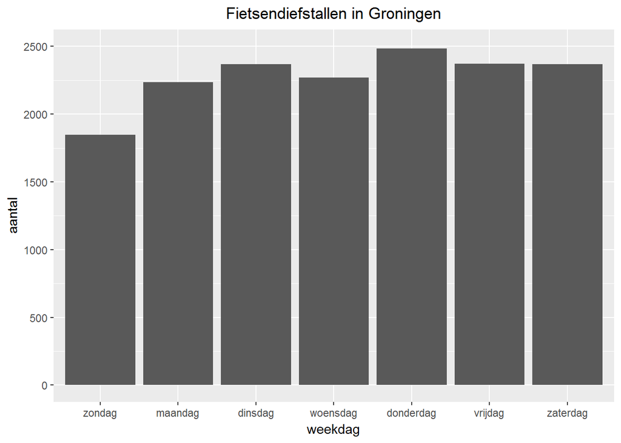

```r
diefstallen <- mutate(diefstallen, b_datum = as.Date(begin), e_datum = as.Date(eind))

m <- sapply(1:nrow(diefstallen), function(x) {
       f <- sapply(0:6, function(weekdag) {
                weekdag %in% strftime(seq(diefstallen$b_datum[x], diefstallen$e_datum[x], by = 'day'), format = '%w')
              })
       f <- f/sum(f)
})

aantal_per_weekdag <- data.frame(weekdag = c('zondag', 'maandag', 'dinsdag', 'woensdag', 'donderdag', 'vrijdag', 'zaterdag'), aantal = apply(m, 1, sum))

ggplot(aantal_per_weekdag, aes(x = weekdag, y = aantal)) +
       geom_bar(stat = "identity") +
       scale_x_discrete(limits = aantal_per_weekdag$weekdag) +
       scale_y_continuous(limits = c(0, 2500), breaks = c(0, 500, 1000, 1500, 2000, 2500)) +
       ggtitle("Fietsendiefstallen in Groningen") +
       theme(plot.title = element_text(hjust = 0.5))
```

Maak een grafiek van de diefstallen in de tijd.

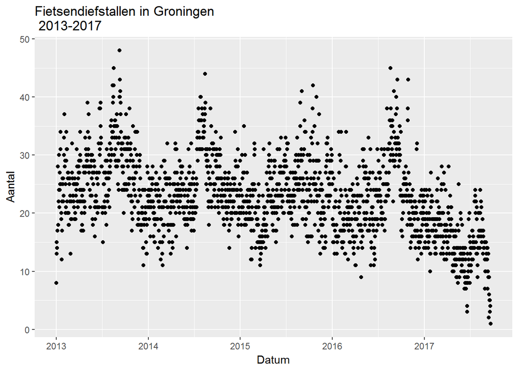

```r
diefstallen <- diefstallen %>% mutate(p = as.numeric(e_datum - b_datum), f = 1/(1 + p))
datum <- seq(min(diefstallen$b_datum), max(diefstallen$e_datum), by = 'day')

t1 <- sapply(datum, function(x) sum(diefstallen$b_datum <= x & diefstallen$e_datum >= x)) %>%
      data.frame(datum = datum, aantal = .)

qplot(x = datum,
      y = aantal,
      data = t1,
      na.rm = TRUE,
      main = "Fietsendiefstallen in Groningen\n 2013-2017",
      xlab = "Datum",
      ylab = "Aantal")
```

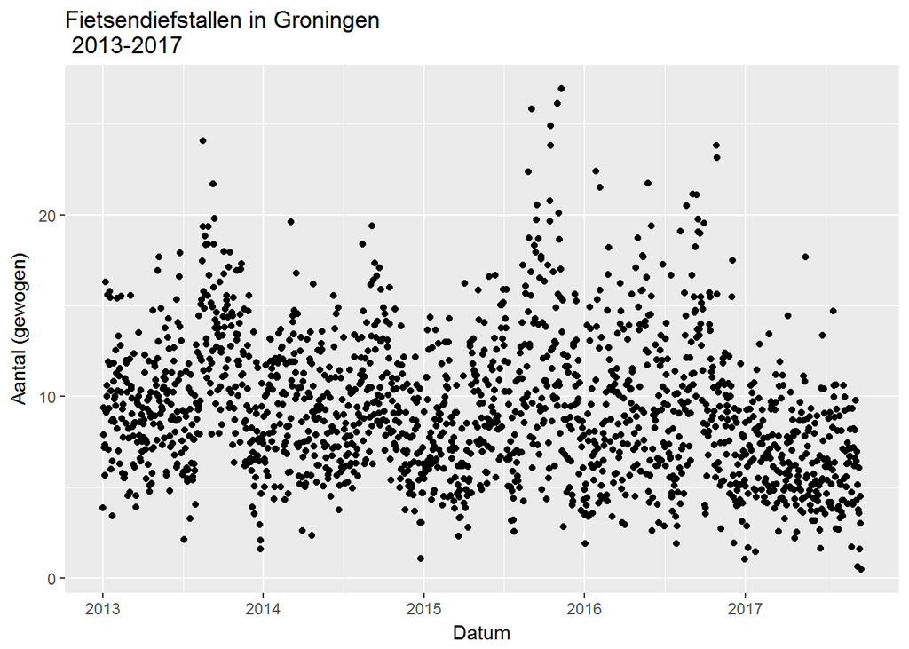

```r
t2 <- sapply(datum, function(x) sum(diefstallen$f[diefstallen$b_datum <= x & diefstallen$e_datum >= x])) %>%
      data.frame(datum = datum, aantal_gewogen = .)

qplot(x = datum,
      y = aantal_gewogen,
      data = t2,
      na.rm = TRUE,
      main = "Fietsendiefstallen in Groningen\n 2013-2017",
      xlab = "Datum",
      ylab = "Aantal (gewogen)")
```

```r
t <- inner_join(t1, t2)
```

Bepaal op welke dag de meeste diefstallen werden gepleegd.

```r
t <- inner_join(t1, t2)
d <- t$datum[which.max(t$aantal_gewogen)]
```

De meeste diefstallen werden gepleegd op 2015-11-10.

Maak een kaartje van de locaties waar fietsen werden gestolen op 2015-11-10.

```r
diefstallen %>%
  filter(b_datum <= d & d <= e_datum) %>%
  st_transform(4326) %>%
  leaflet() %>%
  addMarkers() %>%
  addProviderTiles(providers$CartoDB.Positron)
```

[interactive chart not shown]